# Comparison of the PISA exam results among Mexico, Japan, and the UK

## Preliminary Wrangling

The dataset used for this project is related with results from the 2012 *pisa* exam. The dataset is composed by results for students from OCDE countries.

```python
# import all packages and set plots to be embedded inline
import numpy as np
import pandas as pd
import matplotlib.pyplot as plt
import seaborn as sns
from Functions import *

%matplotlib inline
```

> Load in your dataset and describe its properties through the questions below. Try and motivate your exploration goals through this section.

```python
# Load in the general demographics data.
pisa = pd.read_csv('pisa2012.csv', encoding = "ISO-8859-1", low_memory=False)
pisadict = pd.read_csv('pisadict2012.csv', encoding = "ISO-8859-1")
```

> This project is focused on the performance of students from Japan, the United Kingdom and Mexico, since are countries with results above the average, with average results and with results below the average, respectively. The objective of this project is to understand the factors related with the performance of students when taking the *pisa* exam.

### Gathering data

Obtaining information related with the countries of interest, Mexico, Japan and the United Kingdom.

```python
pisa = pisa.loc[(pisa.CNT == 'Mexico') | (pisa.CNT == 'Japan') | (pisa.CNT == 'United Kingdom')]
pisa = pisa.reset_index(drop=True)
pisa.head()
```

|  | Unnamed: 0 | CNT | SUBNATIO | STRATUM | OECD | NC | SCHOOLID | STIDSTD | ST01Q01 | ST02Q01 | ... | W_FSTR75 | W_FSTR76 | W_FSTR77 | W_FSTR78 | W_FSTR79 | W_FSTR80 | WVARSTRR | VAR_UNIT | SENWGT_STU | VER_STU |
| --- | --- | --- | --- | --- | --- | --- | --- | --- | --- | --- | --- | --- | --- | --- | --- | --- | --- | --- | --- | --- | --- |
| 0 | 189118 | United Kingdom | 8260000 | GBR1314 | OECD | United Kingdom (excl.Scotland) | 1 | 1 | 11 | 1.0 | ... | 4.2169 | 13.5879 | 4.2169 | 4.2169 | 13.5879 | 13.5879 | 29 | 1 | 0.0127 | 22NOV13 |
| 1 | 189119 | United Kingdom | 8260000 | GBR1314 | OECD | United Kingdom (excl.Scotland) | 1 | 2 | 11 | 1.0 | ... | 4.7200 | 21.1565 | 4.7200 | 4.7200 | 21.1565 | 21.1565 | 29 | 1 | 0.0164 | 22NOV13 |
| 2 | 189120 | United Kingdom | 8260000 | GBR1314 | OECD | United Kingdom (excl.Scotland) | 1 | 3 | 11 | 1.0 | ... | 4.2169 | 13.5879 | 4.2169 | 4.2169 | 13.5879 | 13.5879 | 29 | 1 | 0.0127 | 22NOV13 |
| 3 | 189121 | United Kingdom | 8260000 | GBR1314 | OECD | United Kingdom (excl.Scotland) | 1 | 4 | 11 | 1.0 | ... | 4.7200 | 21.1565 | 4.7200 | 4.7200 | 21.1565 | 21.1565 | 29 | 1 | 0.0164 | 22NOV13 |
| 4 | 189122 | United Kingdom | 8260000 | GBR1314 | OECD | United Kingdom (excl.Scotland) | 1 | 5 | 11 | 1.0 | ... | 4.2169 | 13.5879 | 4.2169 | 4.2169 | 13.5879 | 13.5879 | 29 | 1 | 0.0127 | 22NOV13 |

5 rows × 636 columns

### Assessing the data

Presence of missing or undefined values in the dataset, proportion of missing values on each of the dataset columns:

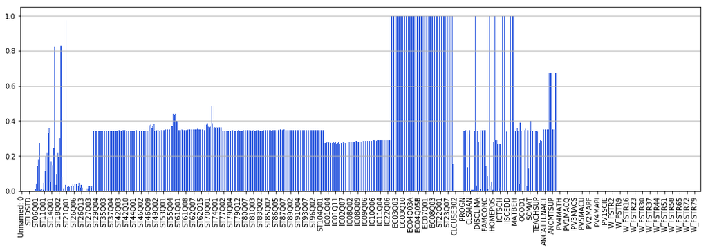

```python
PlotNullCols(pisa, 7)
```

Finding nan patterns among columns and rows of the dataset:

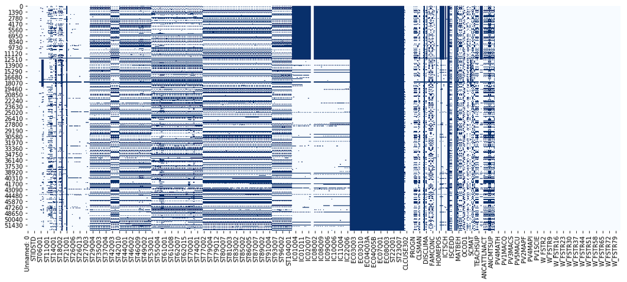

```python
fig, ax = plt.subplots(figsize=(18,7))
sns.heatmap(pisa.isnull(), cbar=False,cmap="Blues");
```

It can be observed in the previous figure that there are different behaviors of nan values. Then, it will be difficult to drop all nan values, given that there exists the possibility to drop all rows of the generated dataset. Removing columns of rows with enough nan values to be considered outliers will only clean a small proportion of the nan values. As result, it was concluded to implement the following steps in order to analyze the generated dataset:

- Generate subsets to study different features of interest related with the performances of the students. This, to analyze more features, while reducing the effects of the *nan* values present.
- Reduce the amount of *nan* values on the created datasets.
- Compare the proportion of information for each of the selected countries. It needs to be similar for each of the selected countries in all the created datasets.
- Assure that the *pisa* exam results maintain the same behavior in all the created datasets. Otherwise, the analysis won’t be possible.
- Re-encode non-numerical variables.
- Create dictionaries to encode or decode features of interest.

### Cleaning the data

Objective:

> Divide the data into various datasets containing different characteristics of interest.

Code:

```python
#Generating dataframe A (ISCED, Class skipped and use of calculator)
Cols1 = ['CNT', 'ST04Q01', 'AGE', 'ST05Q01','ST06Q01', 'ST08Q01','ST09Q01','ST115Q01', 'CLCUSE1', 'PV1MATH', 'PV1READ', 'PV1SCIE']
pisaA = pisa[Cols1]
#Generating dataframe B (Studenets family and resources characteristics)
Cols2 = ['CNT', 'ST04Q01', 'AGE', 'ST13Q01','ST17Q01', 'ST19Q01', 'ST15Q01', 'ST26Q10', 'ST26Q02', 'BFMJ2', 'BMMJ1','PV1MATH', 'PV1READ', 'PV1SCIE']
pisaB = pisa[Cols2]
#Generating dataframe C (Learning outside the school)
Cols3 = ['CNT', 'ST04Q01', 'AGE', 'ST57Q01', 'ST57Q02', 'ST57Q03', 'ST57Q05', 'ST57Q06','PV1MATH', 'PV1READ', 'PV1SCIE']
pisaC = pisa[Cols3]
#Generating dataframe D (Students attitudes)
Cols4 = ['CNT', 'ST04Q01', 'AGE', 'ST88Q01', 'ST88Q02', 'ST88Q03', 'ST88Q04', 'ST89Q02', 'ST89Q03', 'ST89Q05','PV1MATH', 'PV1READ', 'PV1SCIE']
pisaD = pisa[Cols4]
```

Result:

> As results of the previous code, it can be seen that all the created datasets present different distributions for the nan values present on them.

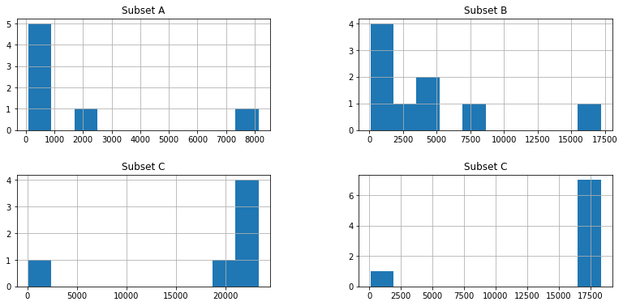

```python
cols = [pisaA.columns[pisaA.isnull().any()], pisaB.columns[pisaB.isnull().any()], pisaC.columns[pisaC.isnull().any()], pisaD.columns[pisaD.isnull().any()]]
names = ['A', 'B', 'C', 'D']
bins = [10, 10, 10, 10]
PlotDistCoun(pisaA, pisaB, pisaC, pisaD, cols, names, bins)
```

Objective:

> Reduce the nan values present in the datasets

Code:

```python
pisaA = pisaA.dropna()
pisaB = pisaB.dropna()
pisaC = pisaC.dropna()
pisaD = pisaD.dropna()
```

Result:

```python
print('NaN values in subset A : ', pisaA.isnull().sum().sum())
print('NaN values in subset B : ', pisaB.isnull().sum().sum())
print('NaN values in subset C : ', pisaC.isnull().sum().sum())
print('NaN values in subset D : ', pisaD.isnull().sum().sum())
```

```
NaN values in subset A :  0
NaN values in subset B :  0
NaN values in subset C :  0
NaN values in subset D :  0
```

Objecive:

> The proportion of the created datasets needs to be the same for each of the selected countries

Code:

```python
pisaA = CNTPorportions(pisaA)
pisaB = CNTPorportions(pisaB)
pisaC = CNTPorportions(pisaC)
pisaD = CNTPorportions(pisaD)
```

Result:

```python
print('Rows for each country in the pisaA dataset: ', pisaA.CNT.value_counts().unique())
print('Rows for each country in the pisaB dataset: ', pisaB.CNT.value_counts().unique())
print('Rows for each country in the pisaC dataset: ', pisaC.CNT.value_counts().unique())
print('Rows for each country in the pisaD dataset: ', pisaD.CNT.value_counts().unique())
```

```
Rows for each country in the pisaA dataset:  [5994]
Rows for each country in the pisaB dataset:  [3887]
Rows for each country in the pisaC dataset:  [3929]
Rows for each country in the pisaD dataset:  [4137]
```

Objective:

> Assure the behavior for the pisa test results for all the created datasets

Code:

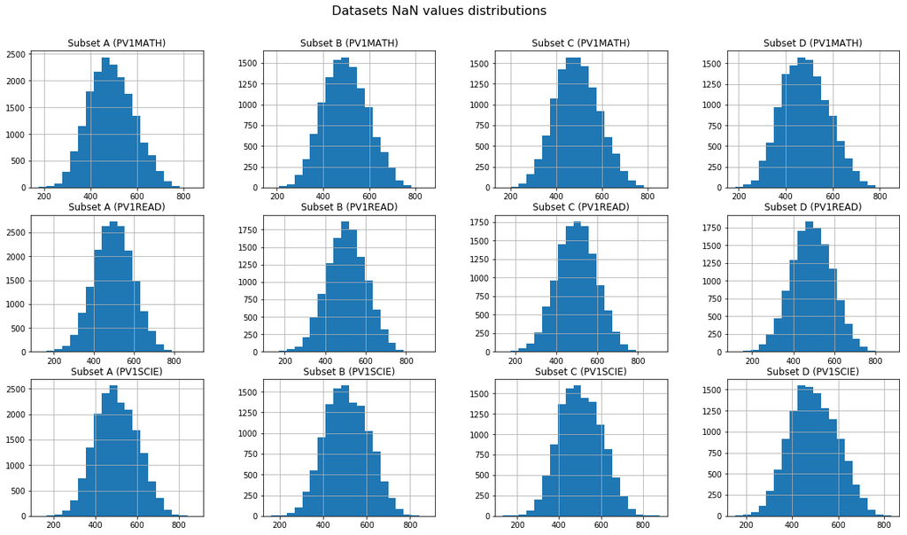

```python
cols = ['PV1MATH', 'PV1READ', 'PV1SCIE']
bins = [20, 20, 20, 20]
dfs = [pisaA, pisaB, pisaC, pisaD]
PlotSubsetsDist(dfs, cols, bins, 'Datasets NaN values distributions')
```

Result:

> The results obtained from the previous section code show that *pisa* results in all created datasets keep the same behavior as normal distributions. This is the base for the use of different datasets with different features to analyze the student performances when taking the *pisa* exam, since the features on different datasets affects the results in the same extent.

Objective:

> Create dictionaries to encode or decode features of interest

Code:

```python
#Dictionary for the dataframe attributes
Dict = {}

Dict['ST04Q01'] = {'Female':1, 'Male': 0}
Dict['ST05Q01'] = {'No  ': 1, 'Yes, for one year or less ': 2, 'Yes, for more than one year':3}
Dict['ST08Q01'] = {'None  ':1, 'One or two times  ':2, 'Three or four times  ':3, 'Five or more times  ':4}
Dict['ST09Q01'] = {'None  ':1, 'One or two times  ':2, 'Three or four times  ':3, 'Five or more times  ':4}
Dict['CLCUSE1'] = {'No calculator':1, 'A Simple calculator':2, 'A Scientific calculator':3, 'A Graphics calculator':4, 'A CAS calculator':5}
Dict['ST19Q01'] = {'Working full-time <for pay> ':1, 'Working part-time <for pay>':2, 'Not working, but looking for a job':3, 'Other (e.g. home duties, retired) ':4}
Dict['ST15Q01'] = {'Working full-time <for pay> ':1, 'Working part-time <for pay>':2, 'Not working, but looking for a job ':3, 'Other (e.g. home duties, retired) ':4}
Dict['ST26Q10'] = {'Yes':1, 'No':2}
Dict['ST26Q02'] = {'Yes':1, 'No':2}
Dict['ST88Q01'] = {'Disagree':3, 'Agree':2, 'Strongly disagree':4, 'Strongly agree':1}
Dict['ST88Q02'] = {'Disagree':3, 'Agree':2, 'Strongly disagree':4, 'Strongly agree':1}
Dict['ST88Q03'] = {'Disagree':3, 'Agree':2, 'Strongly disagree':4, 'Strongly agree':1}
Dict['ST88Q04'] = {'Disagree':3, 'Agree':2, 'Strongly disagree':4, 'Strongly agree':1}
Dict['ST89Q02'] = {'Disagree':3, 'Agree':2, 'Strongly disagree':4, 'Strongly agree':1}
Dict['ST89Q03'] = {'Disagree':3, 'Agree':2, 'Strongly disagree':4, 'Strongly agree':1}
Dict['ST13Q01'] = {'<ISCED level 2> ':3, '<ISCED level 3A> ':1,'She did not complete <ISCED level 1> ':5, '<ISCED level 1> ':4, '<ISCED level 3B, 3C> ':2}
Dict['ST17Q01'] = {'<ISCED level 2> ':3, '<ISCED level 3A> ':1,'He did not complete <ISCED level 1> ':5, '<ISCED level 1> ':4, '<ISCED level 3B, 3C> ':2}
```

```python
#Dictionary for the columns names
DictCols = {}
for index in pisadict.index:
    DictCols[pisadict['Unnamed: 0'].loc[index]] = pisadict['x'].loc[index]
```

```python
#Dictionary for the inverse of the dataframe attributes
DictInv = {}
for key in list(Dict.keys()):
    DictInv[key] = {v: k for k, v in list(Dict[key].items())}
```

Objective:

> Re-encode non-numerical columns

Code:

```python
pisaA = ReEnconding(pisaA, Dict)
pisaB = ReEnconding(pisaB, Dict)
pisaC = ReEnconding(pisaC, Dict)
pisaD = ReEnconding(pisaD, Dict)
```

Result:

```python
pisaB.head()
```

|  | CNT | ST04Q01 | AGE | ST13Q01 | ST17Q01 | ST19Q01 | ST15Q01 | ST26Q10 | ST26Q02 | BFMJ2 | BMMJ1 | PV1MATH | PV1READ | PV1SCIE |
| --- | --- | --- | --- | --- | --- | --- | --- | --- | --- | --- | --- | --- | --- | --- |
| 31387 | Mexico | 1 | 15.83 | 1 | 1 | 1 | 1 | 1 | 1 | 76.65 | 58.77 | 477.7302 | 488.6635 | 421.1488 |
| 23882 | Mexico | 0 | 15.92 | 2 | 2 | 4 | 1 | 1 | 1 | 57.03 | 30.90 | 371.2494 | 388.2835 | 325.7553 |
| 26639 | Mexico | 1 | 15.83 | 1 | 2 | 1 | 4 | 1 | 2 | 62.45 | 62.39 | 455.0631 | 509.4745 | 467.8665 |
| 29996 | Mexico | 1 | 15.33 | 3 | 4 | 1 | 4 | 1 | 1 | 18.07 | 30.90 | 317.6585 | 376.6658 | 393.2674 |
| 37201 | Mexico | 1 | 15.25 | 3 | 1 | 1 | 2 | 1 | 2 | 51.50 | 24.98 | 461.2946 | 551.5729 | 515.2369 |

### What is the structure of your dataset?

The dataset provided was divided into four new datasets to deal with the missing and unknown values, avoiding the dropping of important features. Each of the generated datasets contains different features of interest, each of them represents specific students characteristics that help to understand their performances during the *pisa* test. The datasets are composed by the information of only three countries, as explained next.

### What is/are the main feature(s) of interest in your dataset?

The dataframe contains information related with OCDE countries, however, this analysis is based only on three of them. The selected countries are Japan, the United Kingdom and Mexico, countries selected to represent students with results above the average, with average results and with results below the average, respectively. The goal of this analysis is to understand the variables that affect the students performances when taking the *PISA* exam.

### What features in the dataset do you think will help support your investigation into your feature(s) of interest?

The features in the datasets that can help to support the analysis are those related with the student’s genders, their parents’ occupations and education, the school attendance, the use of tools such calculators and the time used to study outside the school. The objective is to relate these features with the student’s performances during the *PISA* exam, comparing differences between the selected countries.

## Univariate Exploration

> In this section, investigate distributions of individual variables. If you see unusual points or outliers, take a deeper look to clean things up and prepare yourself to look at relationships between variables.

The univariate exploration is implemented in the created datasets, as an example of them, the following table show their structure.

```python
#Example of Data structure
pisaA.head()
```

|  | CNT | ST04Q01 | AGE | ST05Q01 | ST06Q01 | ST08Q01 | ST09Q01 | ST115Q01 | CLCUSE1 | PV1MATH | PV1READ | PV1SCIE |
| --- | --- | --- | --- | --- | --- | --- | --- | --- | --- | --- | --- | --- |
| 25072 | Mexico | 0 | 16.00 | 3 | 6.0 | 1 | 1 | 1.0 | 3 | 405.2890 | 353.6395 | 369.8620 |
| 20023 | Mexico | 0 | 15.58 | 3 | 6.0 | 1 | 1 | 2.0 | 3 | 376.5462 | 418.2763 | 356.5274 |
| 30876 | Mexico | 1 | 15.67 | 3 | 6.0 | 2 | 2 | 2.0 | 3 | 423.4382 | 403.0369 | 391.0295 |
| 28953 | Mexico | 0 | 15.92 | 3 | 6.0 | 2 | 1 | 1.0 | 3 | 354.1128 | 332.9493 | 422.7341 |
| 33180 | Mexico | 1 | 15.67 | 1 | 6.0 | 1 | 1 | 1.0 | 3 | 420.7119 | 453.6345 | 424.9720 |

Since there is an interest in this analysis to understand the factors that increase or decrease the performance of students for three different countries during the *pisa* test, it is required to understand the behaviour of features that can be related with them. The features of interest are:

- Parents educations
- Parents current occupations
- At what age students started their ISCED 1 education
- Students truancy
- Students dependency to the use of calculators
- How much time students learn outside the school

### Mothers highest educations and current occupations

> It can be observed in the graphic below that Mexico is the country where the mothers of the students have the lower ISCED education, followed by the United Kingdom and then Japan.

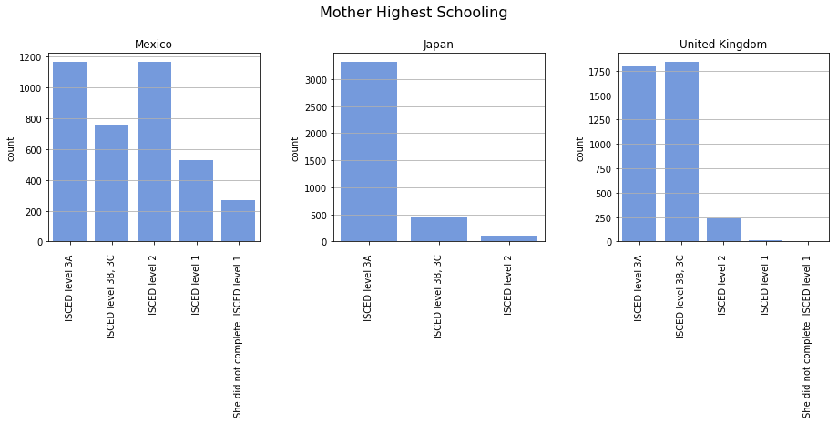

```python
#Plotting distributions of the highest schooling for the Mothers of students in the three countries of interest
names = ['Mexico', 'Japan', 'United Kingdom']
bins = [5, 5, 5]
PlotDistHist(pisaB, 'ST13Q01', names, bins, DictCols['ST13Q01'], DictInv, Figsize=(14,4), orient='h')
```

> Mothers current occupations follow the same behaviour as in the last figure, where Mexico is the country where the student’s mothers spend more time in their home for different reasons. The same proportion of Mexican mothers has full-time jobs. On the other hand, Japanese mothers are the ones that have more half-time jobs and British mothers are the ones that have more full-time jobs.

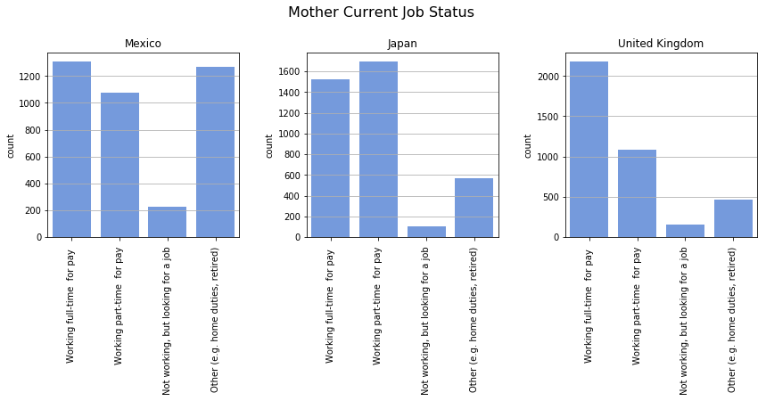

```python
#Plotting distributions of the current job status for the Mothers of students in the three countries of interest
bins = [4, 4, 4]
PlotDistHist(pisaB, 'ST15Q01', names, bins, DictCols['ST15Q01'], DictInv, Figsize=(13,4), orient='h')
```

### Fathers ISCED educations and current occupations

> The highest ISCED education among the student’s fathers for the selected countries can be found in Japan, followed by the United Kingdom and then by Mexico. Japan is the country where the highest number of Fathers have ISCED 3A education, the UK where more fathers have ISCED 3B and 3C education and Mexico is the country with more ISCED 2 and ISCED1 education.

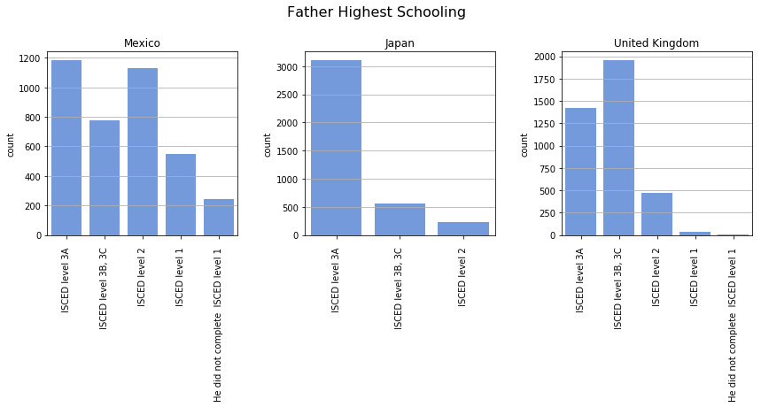

```python
#Plotting distributions of the highest schooling for the Fathers of students in the three countries of interest
PlotDistHist(pisaB, 'ST17Q01', names, bins, DictCols['ST17Q01'], DictInv, Figsize=(13,4), orient='h')
```

> Fathers occupations distributions for the selected countries are very similar, most of them work full-time.

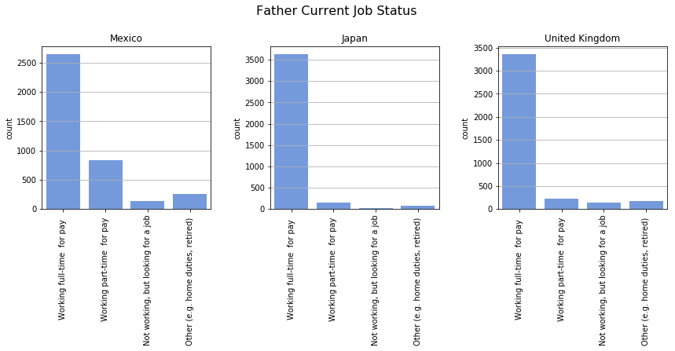

```python
#Plotting distributions of the current job status for the Fathers of students in the three countries of interest
PlotDistHist(pisaB, 'ST19Q01', names, bins, DictCols['ST19Q01'], DictInv, Figsize=(13,4), orient='h')
```

### ISCED 1 started age

> Distribution for ages in which normally students from the selected countries start their ISCED 1 education. It can be observed that in Japan all students start their ISCED education when they are 6 years old, while in the United Kingdom and Mexico the ages vary from 4 to 8 or older ages.

```python
DictCols['ST06Q01'].replace('<',' ').replace('>',' ')
```

```
'Age at  ISCED 1 '
```

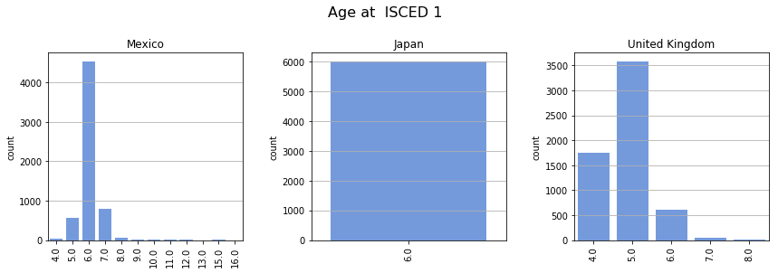

```python
#Plotting distributions of ages when students for the three countries of interest start the ISCED 1 level
bins = [9, 10, 9]
PlotDistHist(pisaA, 'ST06Q01', names, bins, DictCols['ST06Q01'], Figsize=(13,4), orient='h')
```

### Students Truancy

> The Truancy for students of the selected countries is very similar between them. There is not a particular behaviour that let us know why Japanese students get betters performances than British and Mexican students in the *pisa* exams.

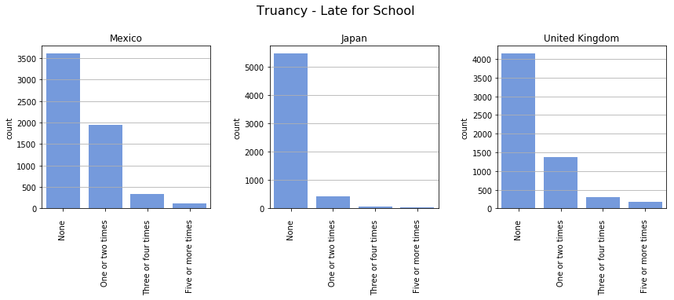

```python
#Plotting the truancy distributions for students related with the countries of interst
PlotDistHist(pisaA, 'ST08Q01', names, bins, DictCols['ST08Q01'], DictInv, Figsize=(13,4), orient='h')
```

### Use of calculators

> The next distributions highlight an interest behaviour, Japanese students use fewer complex calculators or not calculator at all when compared with the use of calculators from British and Mexican students. This may be a factor why Japanese students have better performances in Mathematical topics during the *pisa* exam.

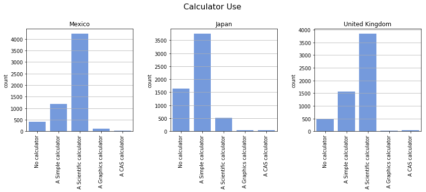

```python
#Plotting the distributions for the students use of calculators for the countries of interst
PlotDistHist(pisaA, 'CLCUSE1', names, bins, DictCols['CLCUSE1'], DictInv, Figsize=(13,4), orient='h')
```

### Time studying outside the school

> The time outside the school dedicated by students of the selected countries to do their homework is very similar. It can't be observed any neglect from the students.

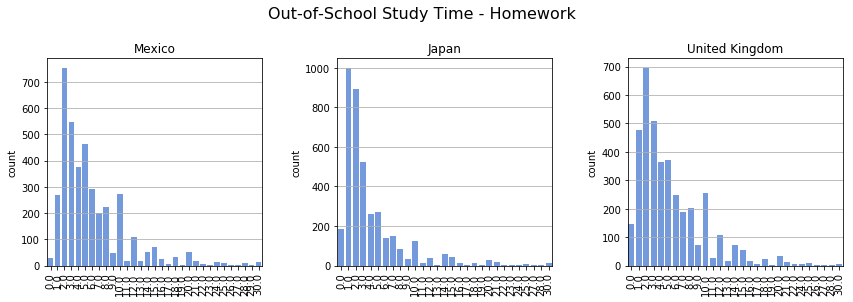

```python
#Plotting distributions for the student's time spent studying doing homework out of the school
PlotDistHist(pisaC, 'ST57Q01', names, bins, DictCols['ST57Q01'], Figsize=(13,4), orient='h')
```

> The time spent with their parents studying present a unusual behaviour for a specific value.

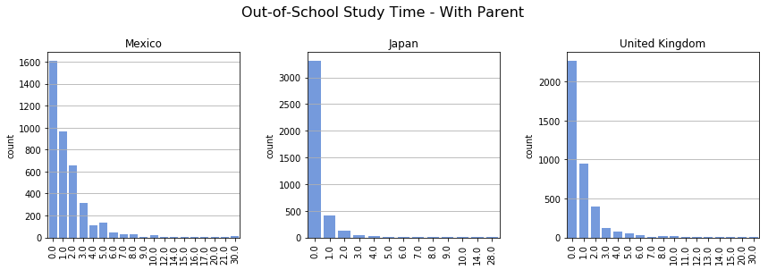

```python
#Plotting distributions for the student's time spent studying doing with their parents
PlotDistHist(pisaC, 'ST57Q05', names, bins, DictCols['ST57Q05'], Figsize=(13,4), orient='h')
```

> The previous figure presents an unusual behaviour for a specific value, for each of the selected countries. Most of the students spent cero hours studying with their parents. After a small research, it was found that the cero value is associated by the OCDE with missing or unknow values for this feature. Therefore, is required to re-encode these values as nan:

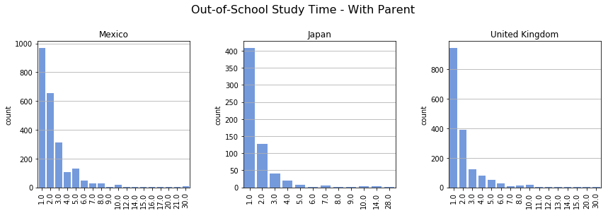

```python
pisaC2 = pisaC.copy()
pisaC2.ST57Q05.replace(0, np.nan, inplace=True)
PlotDistHist(pisaC2, 'ST57Q05', names, bins, DictCols['ST57Q05'], Figsize=(13,4), orient='h')
```

> The re-encoded distributions let us see that the amount of time students spent with their parents studying is not a factor to get better performances in the *pisa* exam, as Japan is the most successful country in the pisa exams with less hours.

> Make sure that, after every plot or related series of plots, that you include a Markdown cell with comments about what you observed, and what you plan on investigating next.

### Discuss the distribution(s) of your variable(s) of interest. Were there any unusual points? Did you need to perform any transformations?

> Most transformations were implemented in the wrangling section. However, in order to increase the understanding of the presented graphics some values were mapped using dictionaries generated in the wrangling section. Nonetheless, most distributions do not present any observable outliers, and the ones observable do not affect the main understanding of the distributions, as was the case for the study time outside the school. At the end of the previous analysis, it was concluded that the variables of interest are the parents higher ISCED educations, the use of calculators, and the age when the students started their ISCED 1 education.

### Of the features you investigated, were there any unusual distributions? Did you perform any operations on the data to tidy, adjust, or change the form of the data? If so, why did you do this?

> Most of the unusual distributions were removed in the previous section. However, it was not considered predefined codes used by the OCDE to represent missing or unknown values for the *ST57Q05* feature. The effect of this was that most students, for each of the countries of interest, studied cero hours with their parents. The predefined code for missing values is cero. Then, after re-encoded the missing values as nan values it was possible to understand the student’s behaviours when studying with their parents.

## Bivariate Exploration

> In this section, investigate relationships between pairs of variables in your data. Make sure the variables that you cover here have been introduced in some fashion in the previous section (univariate exploration).

The first relation to investigate is between the use of calculators and the results obtained from the mathematical section of the pisa exam. However, it can be observed in the figure below that there is not a clear relationship between advamtages of use or not use a specific type of calculator. It was expected that students with relied less on the use of a calculators have better results, but that is not the case.

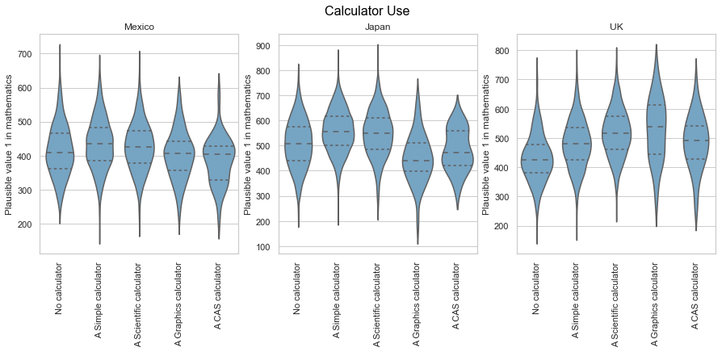

```python
bivariate(pisaA, 'CLCUSE1', 'PV1MATH', ['Mexico', 'Japan', 'UK'], DictCols['CLCUSE1'], DictCols, DictInv)
```

A different relationship explored was between results of the different sections of the pisa exam and the level of education that the parents of the students have. The next figures represent this relationship for a specific pisa section. It will only be presented one the pisa sections, but the behaviour is similar for the three sections.

- Fathers educations Vs. Pisa Mathematical section

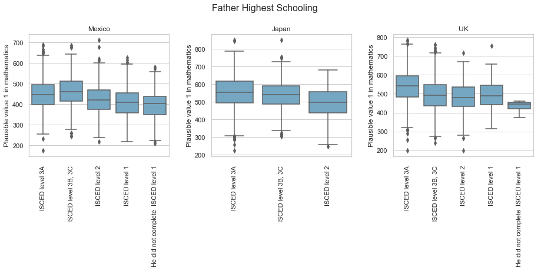

```python
bivariateBox(pisaB, 'ST17Q01', 'PV1MATH', ['Mexico', 'Japan', 'UK'], DictCols['ST17Q01'], DictCols, DictInv)
```

- Mothers educations Vs. Pisa Mathematical section

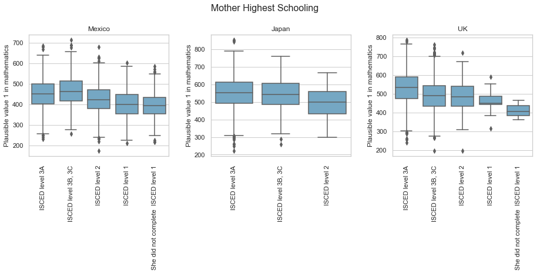

```python
bivariateBox(pisaB, 'ST13Q01', 'PV1MATH', ['Mexico', 'Japan', 'UK'], DictCols['ST13Q01'], DictCols, DictInv)
```

In the previous figures can be seen that, on average, the performance of students during the *pisa* exam is related with the level of education that they parents have. The highest the parents ISCED level of education is, a better performance is expected from their sons when taking the *pisa* exam, on average.

The last relationship to analyse is between the time students spend solving homework’s and they performance during the *pisa* test. The next figure only presents the mentioned relationship only for results of the *pisa* exam from the mathematical section. The rest of the results have the same behaviour as the presented next.

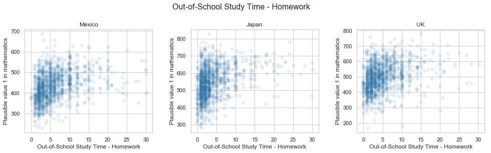

```python
bivariateRegplot(pisaC.sample(4000), 'ST57Q01', 'PV1MATH', ['Mexico', 'Japan', 'UK'], DictCols['ST57Q01'],  DictCols,  alpha=.1, Freg=False, Figsize=(15,4))
```

It can be observed that there is a correlation among the amount of hours dedicated to solve the students homeworks and the students performances when taking the *pisa* exam.

### Talk about some of the relationships you observed in this part of the investigation. How did the feature(s) of interest vary with other features in the dataset?

> Form the selected analysed features, it can be concluded, up this points that the performances of Mexican, Japanese and British students when taking the pisa exam are related with the ISCED levels of education that they parents have and with the number of hours dedicated to solve their homework outside the school. Unfortunately, given the characteristics of the obtained *pisa* dataset, the used features are analysed from different datasets generated from the gathered information. Nevertheless, it is not possible to measure relationships among these generated datasets since the information contained on each of them is not necessarily related with the same students, as explained in the first section of this document.

### Did you observe any interesting relationships between the other features (not the main feature(s) of interest)?

> It was measured how the use of calculators affect the performance of students when solving the mathematical section of the *pisa* exam, but there is not an evident relationship among those features. Additionally, even when is not presented, the previous relationships were analysed for male and female students separately, showing not difference when compared. Thus, the performance of the students when taking the *pisa* exam do not vary too much depending on the student’s gender.

## Multivariate Exploration

> Create plots of three or more variables to investigate your data even further. Make sure that your investigations are justified, and follow from your work in the previous sections.

In the previous section were presented relationships among different features and results obtained from students of three different countries when taking the pisa exam. However, it is important to understand if the mentioned factors have the same effect on students from the selected countries. This is possible comparing results for the different sections of the pisa exam obtained from students of the three selected countries:

> A new dataframe containing results from students of the three selected countries needs to be created:

```python
#Creating a new dataframe containing results from students of the selected countries for the different sections of the pisa exam
pisaRes = pisa.copy()
pisaRes = CNTPorportions(pisaRes)

MX = pisaRes.loc[pisa.CNT == 'Mexico']
JP = pisaRes.loc[pisa.CNT == 'Japan']
UK = pisaRes.loc[pisa.CNT == 'United Kingdom']

#Creating a dataframe with countries results
d = {}
ColsStr = ['MathRes-MX', 'ReadingRes-MX', 'ScienceRes-MX','MathRes-JP', 'ReadingRes-JP', 'ScienceRes-JP',
           'MathRes-UK', 'ReadingRes-UK', 'ScienceRes-UK']
ColsVal = [MX.PV1MATH.values, MX.PV1READ.values, MX.PV1SCIE.values, JP.PV1MATH.values, JP.PV1READ.values, JP.PV1SCIE.values,
           UK.PV1MATH.values, UK.PV1READ.values, UK.PV1SCIE.values]
for col, val in zip(ColsStr, ColsVal):
    d[col] = val

CNTRes = pd.DataFrame(d)
CNTRes.head()
```

|  | MathRes-MX | ReadingRes-MX | ScienceRes-MX | MathRes-JP | ReadingRes-JP | ScienceRes-JP | MathRes-UK | ReadingRes-UK | ScienceRes-UK |
| --- | --- | --- | --- | --- | --- | --- | --- | --- | --- |
| 0 | 531.3990 | 517.4176 | 452.7602 | 598.3876 | 571.7686 | 614.0806 | 554.2997 | 616.4680 | 615.2928 |
| 1 | 452.8042 | 489.5373 | 497.0533 | 639.4376 | 655.0907 | 659.9590 | 564.1143 | 554.1258 | 588.1574 |
| 2 | 522.9864 | 522.0246 | 456.9564 | 697.3127 | 692.7821 | 738.9407 | 578.2131 | 502.2399 | 515.4233 |
| 3 | 422.3477 | 363.4232 | 396.0649 | 637.0229 | 645.1426 | 631.4248 | 599.2444 | 605.4503 | 566.0574 |
| 4 | 368.6010 | 378.6602 | 334.5207 | 669.3488 | 707.2973 | 719.3584 | 507.7193 | 563.3287 | 515.7963 |

> Plotting relationships:

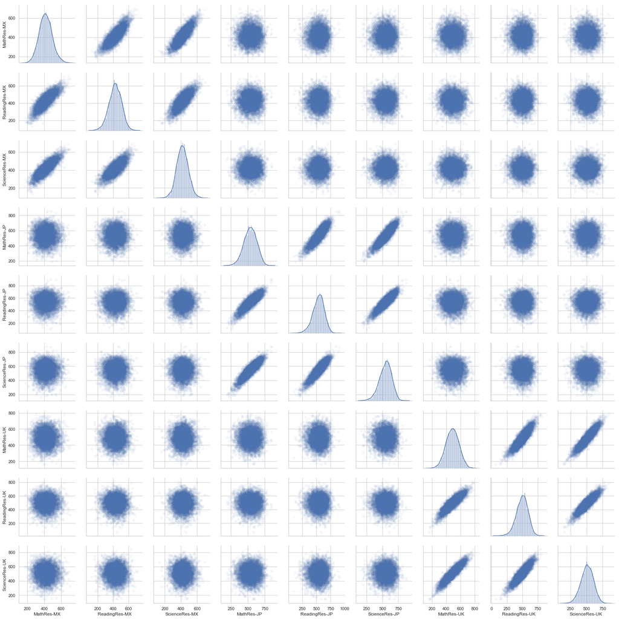

```python
g = sns.PairGrid(CNTRes)
g = g.map_offdiag(reg_plot)
g = g.map_diag(sns.distplot)
```

It can be observed in the figure above that results for the different sections of the pisa exam are highly related among students of the same country. That is not the case for students of different countries, where results obtained by them are not related at all. This can be observed better showing the amount of correlation between the presented results, as follow:

> Plotting the correlation matrix among the presented variables:

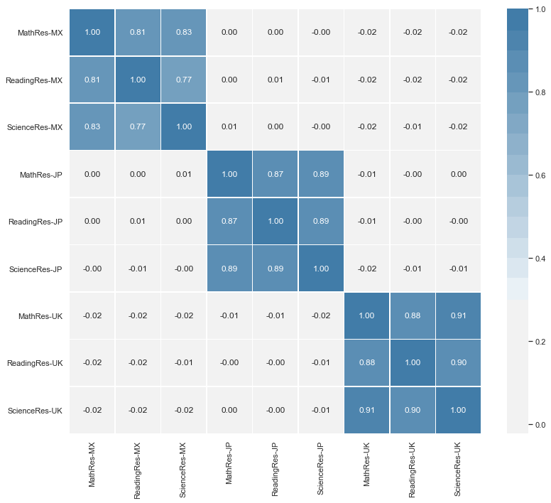

```python
#Ploting a correlation matrix
fig, ax = plt.subplots(figsize=(13,11))
pal = sns.diverging_palette(240, 240, sep=80, n=40)
sns.heatmap(CNTRes.corr(), annot = True, fmt = '.2f', cmap = pal, center = 0, linewidths=.5)
plt.xticks(rotation=90);
plt.yticks(rotation=0);
```

This figure proves the previous conclusions. There exist high correlations among results for the different sections of the pisa exam from students of the same country, while results obtained from students of different countries are almost uncorrelated. Additionally, results obtained from Japanese and British students are highly correlated for the different sections of the pisa exam. On the other hand, obtained results from Mexican students between the different sections of the pisa exam are less correlated.

### Talk about some of the relationships you observed in this part of the investigation. Were there features that strengthened each other in terms of looking at your feature(s) of interest?

> Results obtained from students of the same country are highly correlated, while results among students of different countries are not, even when the results compared are from the same section of the pisa exam. This remarks differences in the way education is provided on each of the mentioned countries.

### Were there any interesting or surprising interactions between features?

> The most surprised interactions were the higher correlation among results obtained from Japanese and British students when solving the different sections of the pisa exam when compared with the Mexican students. This can be related with many unconsidered variables, but there exists the possibility that Mexican education is just not as good as the education provided in Japan or in the United Kingdom, especially when observed that many factors that affect students from the three countries affect them in similar proportions, as shown in the univariate section.

> At the end of your report, make sure that you export the notebook as an html file from the `File > Download as... > HTML` menu. Make sure you keep track of where the exported file goes, so you can put it in the same folder as this notebook for project submission. Also, make sure you remove all of the quote-formatted guide notes like this one before you finish your report!

```python
#Saving the generated dataframes to be usued in the explanatory notebook
pisaA.to_csv('pisa2012A.csv', index=False)
pisaB.to_csv('pisa2012B.csv', index=False)
pisaC.to_csv('pisa2012C.csv', index=False)
pisaD.to_csv('pisa2012D.csv', index=False)
CNTRes.to_csv('CNTRes.csv', index=False)
```